# Bellabeat Case Study

### Summarizing the Data/Checking for NA’s

We will use summary() to get descriptive statistics to check for any obvious issues for each variable. Summary() also comes with the added benefit of providing us with the count of the NA’s for each column, if any.

```r
daily_activity_clean %>%
    select(-Id,
           -Date) %>%
    summary()
```

```
##    TotalSteps    TotalDistance    VeryActiveDistance ModeratelyActiveDistance
##  Min.   :    0   Min.   : 0.000   Min.   : 0.000     Min.   :0.0000
##  1st Qu.: 3790   1st Qu.: 2.620   1st Qu.: 0.000     1st Qu.:0.0000
##  Median : 7406   Median : 5.245   Median : 0.210     Median :0.2400
##  Mean   : 7638   Mean   : 5.490   Mean   : 1.503     Mean   :0.5675
##  3rd Qu.:10727   3rd Qu.: 7.713   3rd Qu.: 2.053     3rd Qu.:0.8000
##  Max.   :36019   Max.   :28.030   Max.   :21.920     Max.   :6.4800
##  LightActiveDistance SedentaryActiveDistance VeryActiveMinutes
##  Min.   : 0.000      Min.   :0.000000        Min.   :  0.00
##  1st Qu.: 1.945      1st Qu.:0.000000        1st Qu.:  0.00
##  Median : 3.365      Median :0.000000        Median :  4.00
##  Mean   : 3.341      Mean   :0.001606        Mean   : 21.16
##  3rd Qu.: 4.782      3rd Qu.:0.000000        3rd Qu.: 32.00
##  Max.   :10.710      Max.   :0.110000        Max.   :210.00
##  FairlyActiveMinutes LightlyActiveMinutes SedentaryMinutes    Calories
##  Min.   :  0.00      Min.   :  0.0        Min.   :   0.0   Min.   :   0
##  1st Qu.:  0.00      1st Qu.:127.0        1st Qu.: 729.8   1st Qu.:1828
##  Median :  6.00      Median :199.0        Median :1057.5   Median :2134
##  Mean   : 13.56      Mean   :192.8        Mean   : 991.2   Mean   :2304
##  3rd Qu.: 19.00      3rd Qu.:264.0        3rd Qu.:1229.5   3rd Qu.:2793
##  Max.   :143.00      Max.   :518.0        Max.   :1440.0   Max.   :4900
```

```r
daily_sleep %>%
    select(TotalMinutesAsleep,
           TotalTimeInBed) %>%
    summary()
```

```
##  TotalMinutesAsleep TotalTimeInBed
##  Min.   : 58.0      Min.   : 61.0
##  1st Qu.:361.0      1st Qu.:403.0
##  Median :433.0      Median :463.0
##  Mean   :419.5      Mean   :458.6
##  3rd Qu.:490.0      3rd Qu.:526.0
##  Max.   :796.0      Max.   :961.0
```

```r
weight_log_clean %>%
    select(-Id,
           -Date) %>%
    summary()
```

```
##   WeightPounds        BMI
##  Min.   :116.0   Min.   :21.45
##  1st Qu.:135.4   1st Qu.:23.96
##  Median :137.8   Median :24.39
##  Mean   :158.8   Mean   :25.19
##  3rd Qu.:187.5   3rd Qu.:25.56
##  Max.   :294.3   Max.   :47.54
```

Based on the output, there does appear to be some high values, for example an individual logged 4900 calories burned. However, this does appear to be within reason. The summary output also states that there are no NA’s in any of out variables so we are good from that regard.

We can now merge the three datasets.

$~$

### Merging the Datasets

For each of the three datasets, we notice that the ID and Date fields are present so we can join the tables on these columns.

Let’s first check the number of unique IDs for each dataset:

```r
n_distinct(daily_activity$Id)
```

```
## [1] 33
```

```r
n_distinct(daily_sleep$Id)
```

```
## [1] 24
```

```r
n_distinct(weight_log$Id)
```

```
## [1] 8
```

From this we see that 33 individuals logged data for activity while only 24 and 8 users logged data for sleep and weight, respectively. In this case we’ll use 2 left joins to join the 3 datasets on the “Id” and “Date” columns so we don’t lose any data.

```r
combined_data <- left_join(left_join(daily_activity_clean,
                                     daily_sleep_clean,
                                     by=c("Id", "Date")), weight_log_clean, by=c("Id", "Date"))
```

```r
glimpse(combined_data)
```

```
## Rows: 940
## Columns: 17
## $ Id                       <dbl> 1503960366, 1503960366, 1503960366, 150396036~
## $ Date                     <date> 2016-04-12, 2016-04-13, 2016-04-14, 2016-04-~
## $ TotalSteps               <dbl> 13162, 10735, 10460, 9762, 12669, 9705, 13019~
## $ TotalDistance            <dbl> 8.50, 6.97, 6.74, 6.28, 8.16, 6.48, 8.59, 9.8~
## $ VeryActiveDistance       <dbl> 1.88, 1.57, 2.44, 2.14, 2.71, 3.19, 3.25, 3.5~
## $ ModeratelyActiveDistance <dbl> 0.55, 0.69, 0.40, 1.26, 0.41, 0.78, 0.64, 1.3~
## $ LightActiveDistance      <dbl> 6.06, 4.71, 3.91, 2.83, 5.04, 2.51, 4.71, 5.0~
## $ SedentaryActiveDistance  <dbl> 0, 0, 0, 0, 0, 0, 0, 0, 0, 0, 0, 0, 0, 0, 0, ~
## $ VeryActiveMinutes        <dbl> 25, 21, 30, 29, 36, 38, 42, 50, 28, 19, 66, 4~
## $ FairlyActiveMinutes      <dbl> 13, 19, 11, 34, 10, 20, 16, 31, 12, 8, 27, 21~
## $ LightlyActiveMinutes     <dbl> 328, 217, 181, 209, 221, 164, 233, 264, 205, ~
## $ SedentaryMinutes         <dbl> 728, 776, 1218, 726, 773, 539, 1149, 775, 818~
## $ Calories                 <dbl> 1985, 1797, 1776, 1745, 1863, 1728, 1921, 203~
## $ TotalMinutesAsleep       <dbl> 327, 384, NA, 412, 340, 700, NA, 304, 360, 32~
## $ TotalTimeInBed           <dbl> 346, 407, NA, 442, 367, 712, NA, 320, 377, 36~
## $ WeightPounds             <dbl> NA, NA, NA, NA, NA, NA, NA, NA, NA, NA, NA, N~
## $ BMI                      <dbl> NA, NA, NA, NA, NA, NA, NA, NA, NA, NA, NA, N~
```

Everything looks good so far and we can proceed with our exploratory data analysis!

$~$

## Exploratory Data Analysis

### Correlation Matrices

To begin, we will create some correlation matrices to get a general idea of what relationships exist between our variables.

Please note that I omitted the variables related to distance due to redundancy with the “Minutes” variables as well as improving the viewability of the visualization.

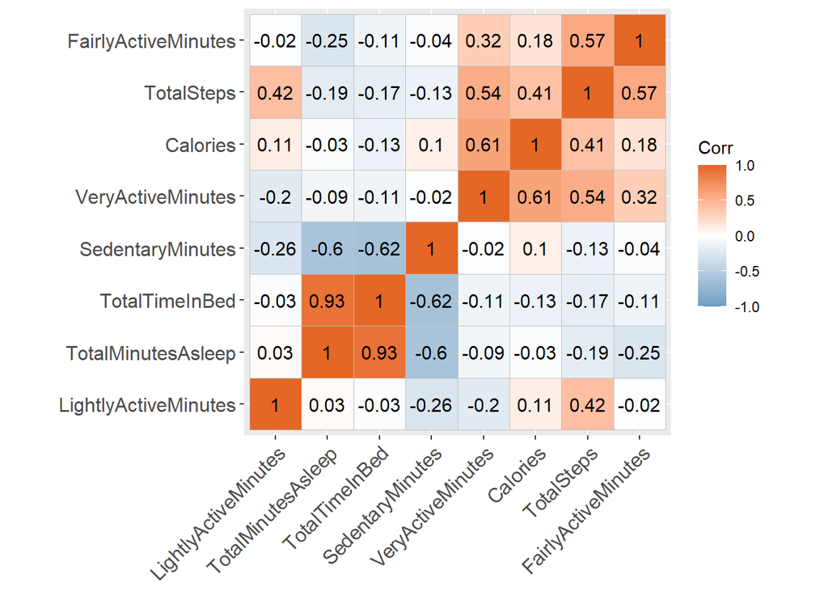

```r
combined_data %>%
    filter(!is.na(TotalMinutesAsleep)) %>% # Filtering out the data that do not have any sleep logged
    select(-Id, -Date, -WeightPounds, -BMI, -ends_with("Distance")) %>%
    cor() %>%
    round(2) %>%
    ggcorrplot(hc.order = TRUE,
               ggtheme = ggplot2::theme_gray,
               colors = c("#6D9EC1", "white", "#E46726"),
               lab=TRUE)
```

Now this is a lot of information so we will focus on the relationships that have a r-value of > 0.5 or < -0.5.

We do see some moderately strong to strong positive correlations with the following:

- Total Steps vs Very Active Minutes (r = 0.54)
- Calories vs Very Active Minutes (r = 0.61)
- Fairly Active Minutes vs Total Steps (r = 0.57)
- Total Time in Bed vs Total Minutes Asleep (r = 0.93)

These relationships intuitively all make sense as more activity results in more more calories burned and more steps taken. The relationship between total time in bed and time asleep is also obvious.

We also see some moderately strong negative correlations with the following:

- Total Time in Bed vs Sedentary Minutes (r = -0.62)
- Total Time Asleep vs Sedentary Minutes (r = -0.6)

This suggests that as the amount of sleep increases, the amount of minutes of being sedentary decreases.

$~$

We will also create a similar correlation matrix that includes the variables associated to weight. We are doing this because there are only 35 rows of data that include both sleep and weight information logged which may result in unreliable findings due to a small sample size. Nonetheless, let’s create the correlation matrix and see if any relationships exist between weight and the other variables. I have excluded BMI from the matrix due to the redundancy with weight.

```r
#Subsetting the data for the correlation matrix
combined_data %>%
    filter(!is.na(WeightPounds) & !is.na(TotalMinutesAsleep)) %>% # Filtering out the data that do not have any weight nor sleep logged
    select(-Id, -Date, -BMI, -ends_with("Distance")) %>%
    glimpse()
```

```
## Rows: 35
## Columns: 9
## $ TotalSteps           <dbl> 14727, 15103, 356, 3428, 12231, 10199, 5652, 1551~
## $ VeryActiveMinutes    <dbl> 41, 50, 0, 0, 200, 50, 8, 0, 0, 50, 5, 13, 35, 48~
## $ FairlyActiveMinutes  <dbl> 15, 24, 0, 0, 37, 14, 24, 0, 0, 3, 13, 42, 41, 4,~
## $ LightlyActiveMinutes <dbl> 277, 254, 32, 190, 159, 189, 142, 86, 217, 280, 2~
## $ SedentaryMinutes     <dbl> 798, 816, 986, 1121, 525, 796, 548, 862, 837, 741~
## $ Calories             <dbl> 2004, 1990, 2151, 1692, 4552, 1994, 1718, 1466, 1~
## $ TotalMinutesAsleep   <dbl> 277, 273, 398, 115, 549, 366, 630, 508, 370, 357,~
## $ TotalTimeInBed       <dbl> 309, 296, 422, 129, 583, 387, 679, 535, 386, 366,~
## $ WeightPounds         <dbl> 115.9631, 115.9631, 294.3171, 154.1031, 199.9593,~
```

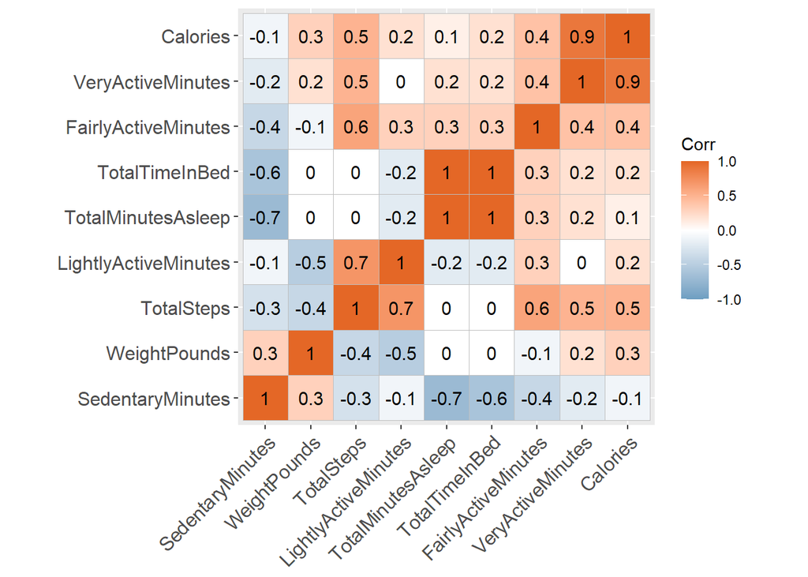

```r
    combined_data %>%
    filter(!is.na(WeightPounds) & !is.na(TotalMinutesAsleep)) %>% # Filtering out the data that do not have any weight nor sleep logged
    select(-Id, -Date, -BMI, -ends_with("Distance")) %>%
    cor() %>%
    round(1) %>%
    ggcorrplot(hc.order = TRUE,
               ggtheme = ggplot2::theme_gray,
               colors = c("#6D9EC1", "white", "#E46726"),
               lab=TRUE)
```

Focusing only on the correlations related to weight, we can see that the only moderately strong relationship is a negative relationship between weight and minutes doing light activity.

$~$

### Trends in Activity

Next, let’s see if there is any relationship between day of the week and activity intensity for the participants.

Creating a column for day of the week and setting it as a factor:

```r
combined_data$DayOfWeek <-
    weekdays(combined_data$Date) %>%
        factor(levels = c("Sunday", "Monday", "Tuesday", "Wednesday",
                          "Thursday", "Friday", "Saturday"))
```

```r
combined_data %>%
    group_by(DayOfWeek) %>%
    summarize(VeryActive = round(mean(VeryActiveMinutes), 2),
              FairlyActive = round(mean(FairlyActiveMinutes), 2),
              LightlyActive = round(mean(LightlyActiveMinutes), 2),
              Sedentary = round(mean(SedentaryMinutes), 2)) %>%
    pivot_longer(!DayOfWeek, names_to = "Intensity", values_to = "Minutes") -> activity_df
```

Setting intensity level as a factor:

```r
activity_df$Intensity <-
    activity_df$Intensity %>%
        factor(levels = c("VeryActive", "FairlyActive", "LightlyActive", "Sedentary"))

head(activity_df)
```

```
## # A tibble: 6 x 3
##   DayOfWeek Intensity     Minutes
##   <fct>     <fct>           <dbl>
## 1 Sunday    VeryActive       20.0
## 2 Sunday    FairlyActive     14.5
## 3 Sunday    LightlyActive   174.
## 4 Sunday    Sedentary       990.
## 5 Monday    VeryActive       23.1
## 6 Monday    FairlyActive     14
```

Creating the visualization:

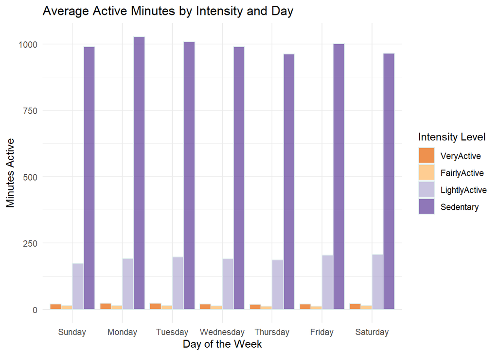

```r
activity_df %>%
    ggplot(aes(x=DayOfWeek, y=Minutes, fill=Intensity)) +
    geom_col(color='azure2', alpha=0.7, position="dodge") +
    scale_fill_brewer(palette = "PuOr") +
    theme_minimal() +
    labs(title = "Average Active Minutes by Intensity and Day",
         x = "Day of the Week",
         y= "Minutes Active",
         fill = "Intensity Level")
```

We obverse that the bulk of the activity minutes were spent being sedentary and there does not seem to be any specific pattern day by day.

Let’s also take a look at the visualization without the sedentary intensity level:

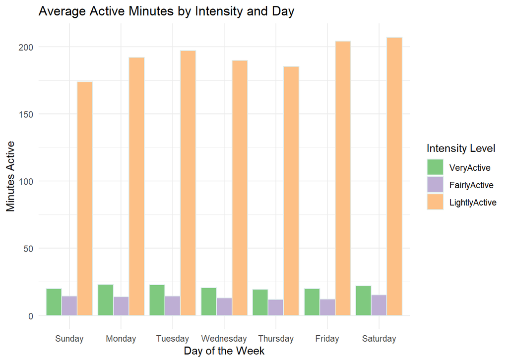

```r
activity_df %>%
    filter(Intensity != "Sedentary") %>%
    ggplot(aes(x=DayOfWeek, y=Minutes, fill=Intensity)) +
    geom_col(color='azure2', position="dodge") +
    scale_fill_brewer(palette = "Accent") +
    theme_minimal() +
    labs(title = "Average Active Minutes by Intensity and Day",
         x = "Day of the Week",
         y= "Minutes Active",
         fill = "Intensity Level")
```

We see that minutes of light intensity activity doesn’t really have a particular pattern either.

Lastly, let’s remove lightly active intensity and focus on just the very active and fairly active intensities:

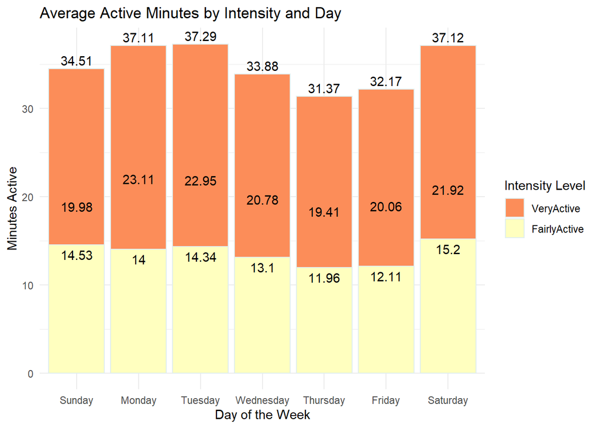

```r
activity_df %>%
    filter(!Intensity %in% c("LightlyActive", "Sedentary")) %>%
    ggplot(aes(x=DayOfWeek, y=Minutes, fill=Intensity)) +
    geom_col(color='azure2') +
    geom_text(aes(label = Minutes), vjust = 1.5) +
    stat_summary(fun = sum, aes(label = ..y.., group = DayOfWeek), geom = "text", vjust= -.35) +
    scale_fill_brewer(palette = "Spectral") +
    theme_minimal() +
    labs(title = "Average Active Minutes by Intensity and Day",
         x = "Day of the Week",
         y= "Minutes Active",
         fill = "Intensity Level")
```

According to Mayo Clinic, most healthy adults should aim for at least 30 minutes of moderate activity a day[^1]. This graph shows that on average these individuals are indeed hitting those 30 minutes of moderate activity per day (assuming fairly active intensity equates to at least moderate activity by Mayo Clinic’s definition).

$~$

### Trends in Sleep

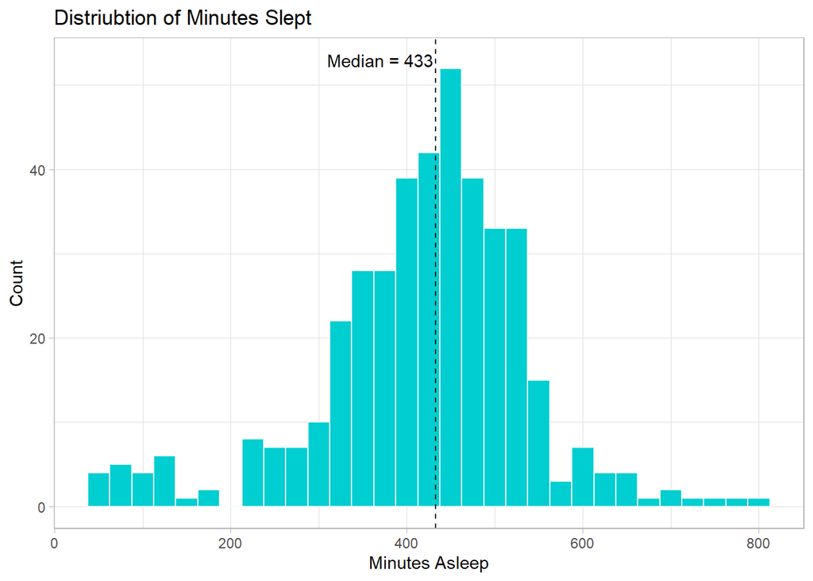

```r
combined_data %>%
    filter(!is.na(TotalMinutesAsleep)) %>%
    ggplot(aes(x=TotalMinutesAsleep)) +
    geom_histogram(binwidth= 25, fill='darkturquoise', color="azure1") +
    theme_light() +
    labs(title = "Distriubtion of Minutes Slept",
         x = "Minutes Asleep",
         y = "Count") +
    geom_vline(aes(xintercept=median(TotalMinutesAsleep)), color="black", linetype="dashed") +
    annotate("text", x=370, y=53, label="Median = 433")
```

The distribution of logged sleep roughly follows a normal distribution. The median amount of sleep logged for a given day is **7 hours and 13 minutes**. According to the Sleep Foundation, adults between 18 and 64 are recommended to get 7 to 9 hours of sleep per day[^2].

Let’s also take a look at average sleep duration at different days of the week:

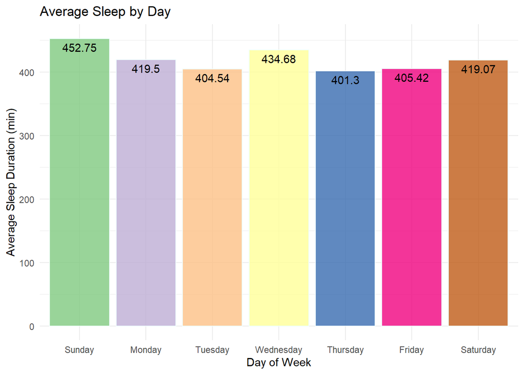

```r
combined_data %>%
    filter(!is.na(TotalMinutesAsleep)) %>%
    group_by(DayOfWeek) %>%
    summarize(AvgSleep = mean(TotalMinutesAsleep)) %>%
    ggplot(aes(x=DayOfWeek, y=AvgSleep, fill=DayOfWeek)) +
    geom_col(color = "azure1", alpha=0.8) +
    geom_text(aes(label = round(AvgSleep,2)), vjust = 1.5) +
    scale_fill_brewer(palette = "Accent") +
    theme_minimal() +
        labs(title = "Average Sleep by Day",
         x = "Day of Week",
         y = "Average Sleep Duration (min)") +
    theme(legend.position='none')
```

It appears that average sleep duration is below the recommended 7 hours for 5 out of the 7 days (Monday, Tuesday, Thursday, Friday, Saturday).

$~$

One last thing we can look into is **sleep latency**, that is the time it takes for you to fall asleep. According to Healthline, it typically takes 10 to 20 for an individual to fall asleep - a sleep latency outside of that range may indicate an underlying sleep condition[^3].

We will make the assumption that the variable “TotalTimeInBed” only includes the time sleeping and the time attempting to sleep. Let’s go ahead and calculate the average and median sleep latency and plot the distribution:

```r
combined_data %>%
    filter(!is.na(TotalMinutesAsleep)) %>%
    summarize(AverageSleepLatency = mean(TotalTimeInBed - TotalMinutesAsleep),
              MedianSleepLatency = median(TotalTimeInBed - TotalMinutesAsleep))
```

```
## # A tibble: 1 x 2
##   AverageSleepLatency MedianSleepLatency
##                 <dbl>              <dbl>
## 1                39.3               25.5
```

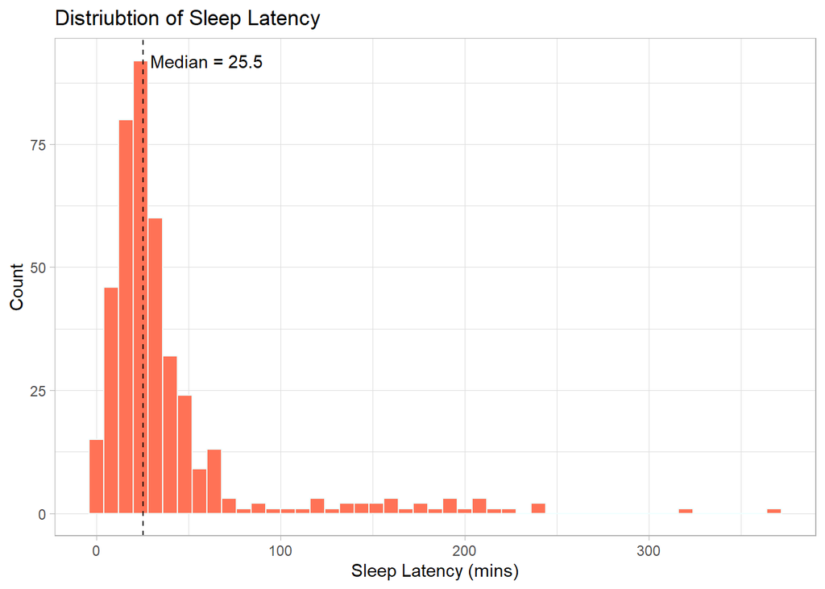

```r
combined_data %>%
    filter(!is.na(TotalMinutesAsleep)) %>%
    mutate(SleepLatency = TotalTimeInBed - TotalMinutesAsleep) %>%
    ggplot(aes(x=SleepLatency)) +
    geom_histogram(binwidth= 8, fill='coral1', color="azure1") +
    theme_light() +
    labs(title = "Distriubtion of Sleep Latency",
         x = "Sleep Latency (mins)",
         y = "Count") +
    geom_vline(aes(xintercept=median(SleepLatency)), color="black", linetype="dashed") +
    annotate("text", x=60, y=92, label="Median = 25.5")
```

$~$

Since it seems like the average sleep latency is on the higher side it may be possible that sleep latency has an effect on minutes of activity. Let’s plot it vs the 4 different intensities to confirm.

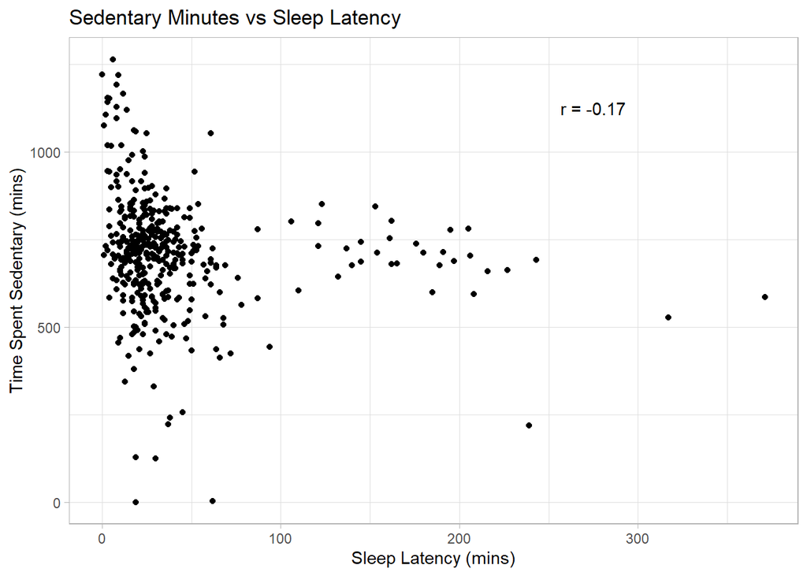

```r
combined_data %>%
    filter(!is.na(TotalMinutesAsleep)) %>%
    mutate(SleepLatency = TotalTimeInBed - TotalMinutesAsleep) %>%
    ggplot(aes(x=SleepLatency, y=SedentaryMinutes)) +
    geom_point() +
    theme_light() +
    labs(title = "Sedentary Minutes vs Sleep Latency",
         x = "Sleep Latency (mins)",
         y = "Time Spent Sedentary (mins)") +
    annotate("text", x=275, y=1125, label="r = -0.17")
```

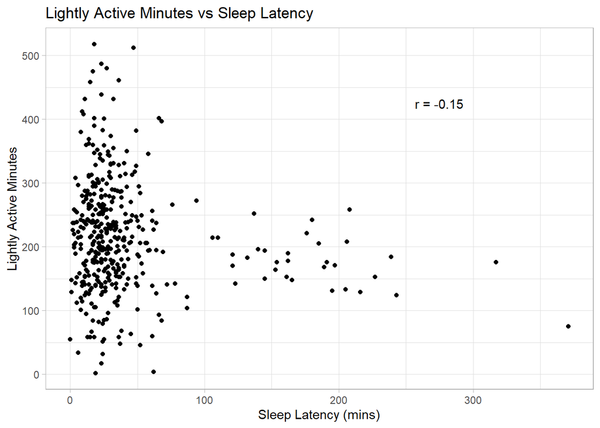

```r
combined_data %>%
    filter(!is.na(TotalMinutesAsleep)) %>%
    mutate(SleepLatency = TotalTimeInBed - TotalMinutesAsleep) %>%
    ggplot(aes(x=SleepLatency, y=LightlyActiveMinutes)) +
    geom_point() +
    theme_light() +
    labs(title = "Lightly Active Minutes vs Sleep Latency",
         x = "Sleep Latency (mins)",
         y = "Lightly Active Minutes") +
    annotate("text", x=275, y=425, label="r = -0.15")
```

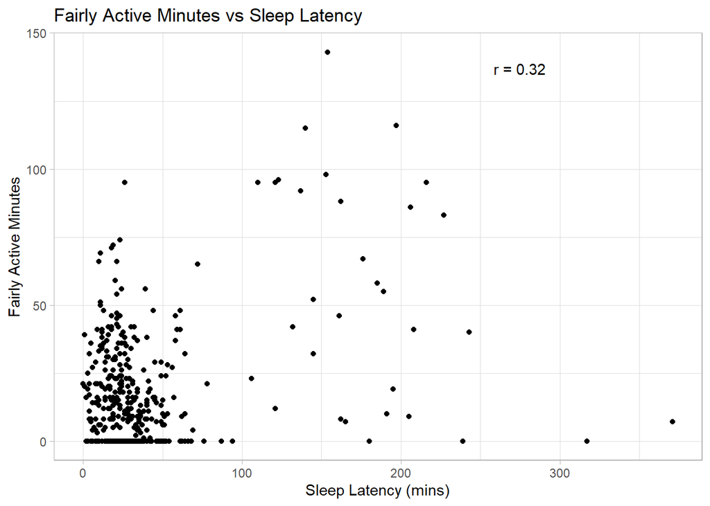

```r
combined_data %>%
    filter(!is.na(TotalMinutesAsleep)) %>%
    mutate(SleepLatency = TotalTimeInBed - TotalMinutesAsleep) %>%
    ggplot(aes(x=SleepLatency, y=FairlyActiveMinutes)) +
    geom_point() +
    theme_light() +
    labs(title = "Fairly Active Minutes vs Sleep Latency",
         x = "Sleep Latency (mins)",
         y = "Fairly Active Minutes") +
    annotate("text", x=275, y=137, label="r = 0.32")
```

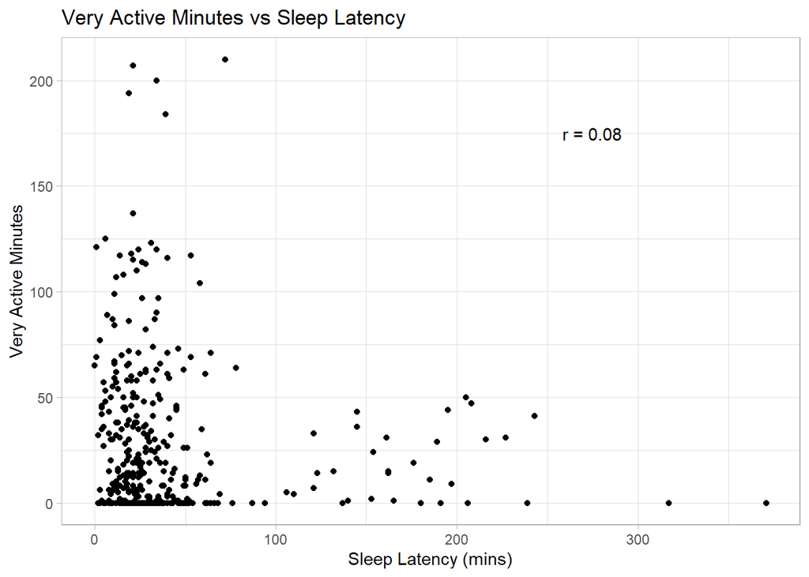

```r
combined_data %>%
    filter(!is.na(TotalMinutesAsleep)) %>%
    mutate(SleepLatency = TotalTimeInBed - TotalMinutesAsleep) %>%
    ggplot(aes(x=SleepLatency, y=VeryActiveMinutes)) +
    geom_point() +
    theme_light() +
    labs(title = "Very Active Minutes vs Sleep Latency",
         x = "Sleep Latency (mins)",
         y = "Very Active Minutes") +
    annotate("text", x=275, y=175, label="r = 0.08")
```

We notice that there is only a weak positive correlation between fairly active minutes and sleep latency while for the other intensities there is no relationship with sleep latency.

$~$

## Conclusion and Parting Thoughts

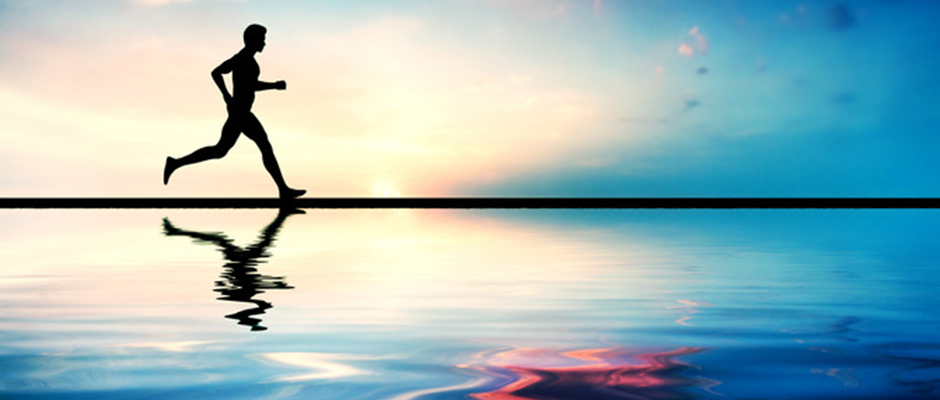

[Image Source](https://images.app.goo.gl/CDVpyP477zVsAdPv7)

$~$

**Findings:**

- There were a fair number of individuals that were getting too much sleep, too little sleep, or had a high sleep latency. Bellabeat could look into providing users recommendations when any of their sleeping patterns fall out of the optimal range.
- Logging was inconsistent especially with recording weight. Bellabeat should look into ways to make logging more consistent, possibly sending a notification to reminding users via the Bellabeat app. With weight in particular, potentially a smart scale could help users record weight by automatically updating their weight in the app when they use the scale.

**Suggestions for Further Investigation:**

There are definitely several things we can improve with regards to the data if we want to do any follow up analyses:

- Survey more individuals over a longer period of time.
- For any data that needs manual logging, make sure individuals are consistently logging them.
- Collect some basic demographic information with regards to the participants to ensure we have a representative sample.
- Since we did not have any water intake data it would definitely be helpful to obtain this, if available.

$~$

Thanks for reading! The files, data, and images for this case study can be found on [GitHub](https://github.com/bxwu/bellabeatcasestudy).

[^1]: Edward R. Laskowski, M. D. (2019, April 27). How much exercise do you really need? Mayo Clinic. https://www.mayoclinic.org/healthy-lifestyle/fitness/expert-answers/exercise/faq-20057916.
[^2]: Sleep Statistics - Facts and Data About Sleep 2020 | Sleep Foundation. (2021). Retrieved from https://www.sleepfoundation.org/how-sleep-works/sleep-facts-statistics
[^3]: Silver, N. (2020, June 5). How long does it take to fall asleep? Average time and tips. Healthline. https://www.healthline.com/health/healthy-sleep/how-long-does-it-take-to-fall-asleep#normal-sleep.